# Нахождение интегралов с помощью метода Монте-Карло

## 1. Для функций одной переменной

Если $x_i \in [a, b]$, где $i = 0, 1, ... , n$, то, используя метод Монте-Карло, можно найти интеграл следующим образом:

$\large\int_a^b f(x)\;\mathrm{d}x = \frac{(b-a)}{N}\Sigma_{i=0}^N f(x_i)$

Рассмотрим на примере следующей функции:

$\large f(x) = \frac{1}{\sqrt{(x+3)} + \sqrt{(x+3)^2}}$

$\large\int_{-2}^1 \frac{1}{\sqrt{(x+3)} + \sqrt{(x+3)^2}}\;\mathrm{d}x$

Пошаговая инструкция расчета:

1. Определение функции
2. Определение нижней и верхней границ, а также число генерируемых рандомных чисел
3. Генерация рандомных чисел
4. Нахождение суммы
5. Вычисление интеграла по формуле

```python
import pandas as pd
import math
import numpy as np
import matplotlib.pyplot as plt
import seaborn as sns
from scipy.integrate import quad, nquad, quadrature, odeint
from typing import Tuple, Callable
```

```
Введите нижний предел: -2
Введите верхний предел: 1
Количество рандомных чисел: 10
```

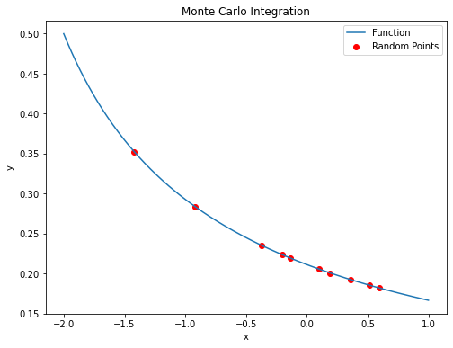

```
Интеграл методом Монте-Карло: 0.6844
Точное значение интеграла: 0.8109
Относительная ошибка: 15.5992%

========================================

Количество рандомных чисел: 50
```

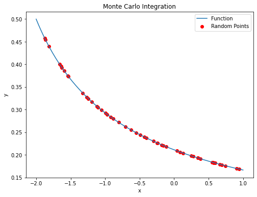

```
Интеграл методом Монте-Карло: 0.8003
Точное значение интеграла: 0.8109
Относительная ошибка: 1.3078%

========================================

Количество рандомных чисел: 100
```

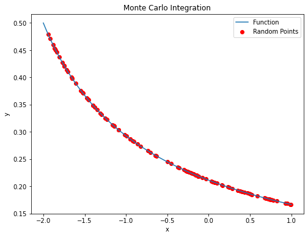

```
Интеграл методом Монте-Карло: 0.8421
Точное значение интеграла: 0.8109
Относительная ошибка: 3.8455%

========================================

Количество рандомных чисел: 500
```

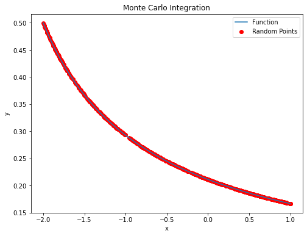

```
Интеграл методом Монте-Карло: 0.8161
Точное значение интеграла: 0.8109
Относительная ошибка: 0.6424%

========================================

Количество рандомных чисел: 1000
```

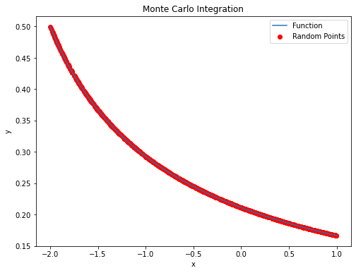

```
Интеграл методом Монте-Карло: 0.8136
Точное значение интеграла: 0.8109
Относительная ошибка: 0.3240%

========================================

Количество рандомных чисел: 5000
```

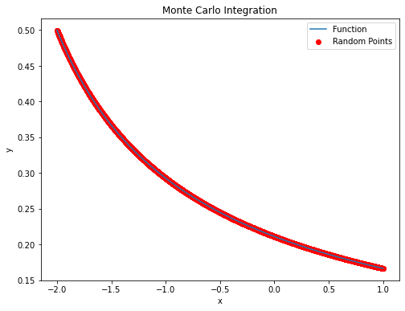

```
Интеграл методом Монте-Карло: 0.8078
Точное значение интеграла: 0.8109
Относительная ошибка: 0.3867%

========================================

Количество рандомных чисел: 10000
```

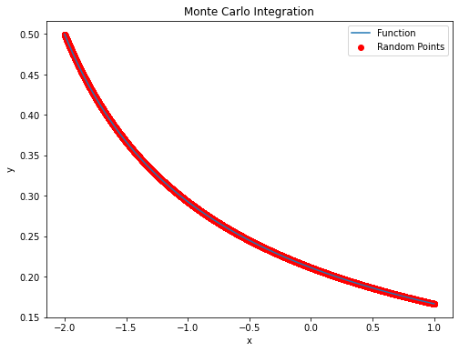

```
Интеграл методом Монте-Карло: 0.8149
Точное значение интеграла: 0.8109
Относительная ошибка: 0.4914%

========================================

Количество рандомных чисел: 50000
```

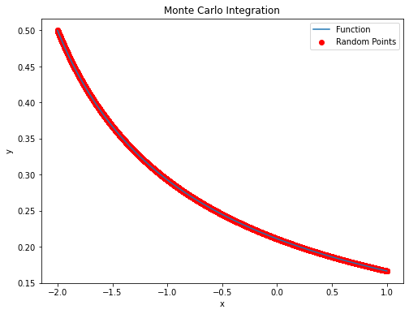

```
Интеграл методом Монте-Карло: 0.8100
Точное значение интеграла: 0.8109
Относительная ошибка: 0.1096%

========================================

Количество рандомных чисел: 100000
```

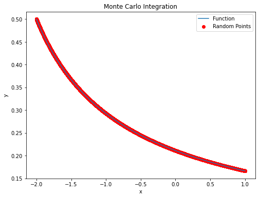

```
Интеграл методом Монте-Карло: 0.8103
Точное значение интеграла: 0.8109
Относительная ошибка: 0.0809%

========================================
```

```python
class MonteCarloIntegration:
    def __init__(self, func, a, b, N):
        self.func = func
        self.a = a
        self.b = b
        self.N = N
        self.array = np.random.uniform(a, b, N)

    def calculate_integral(self):
        summa = np.sum(self.func(self.array))
        integration = (self.b - self.a) / self.N * summa
        return integration

    def calculate_exact_integral(self):
        result, _ = quad(self.func, self.a, self.b)
        return result

    def visualize_function(self):
        x_vals = np.linspace(self.a, self.b, 1000)
        y_vals = self.func(x_vals)

        plt.figure(figsize=(8, 6))
        plt.plot(x_vals, y_vals, label='Function')
        plt.scatter(self.array, self.func(self.array), color='red', label='Random Points')
        plt.title('Monte Carlo Integration')
        plt.xlabel('x')
        plt.ylabel('y')
        plt.legend()
        plt.show()

if __name__ == "__main__":

    def custom_function(x):
        return 1 / (np.sqrt(x + 3) + np.sqrt((x + 3)**2))

    a = float(input("Введите нижний предел: "))
    b = float(input("Введите верхний предел: "))

    N_s = [10, 50, 100, 500, 1000, 5000, 10000, 50000, 100000]

    for N in N_s:

        print("Количество рандомных чисел:", N)

        monte_carlo = MonteCarloIntegration(custom_function, a, b, N)

        monte_carlo.visualize_function()

        integration = monte_carlo.calculate_integral()
        print(f"Интеграл методом Монте-Карло: {integration:.4f}")

        exact_integration = monte_carlo.calculate_exact_integral()
        print(f"Точное значение интеграла: {exact_integration:.4f}")

        error = abs(exact_integration - integration) / exact_integration * 100
        print(f"Относительная ошибка: {error:.4f}%")

        print("\n========================================\n")
```

## 2. Для функций двух переменных

Если $x_i \in [a, b]$, $y_i in [c, d]$, где $i = 0, 1, ... , n$, то, используя метод Монте-Карло, можно найти кратный интеграл следующим образом:

$\large\int_a^b \int_c^d f(x, y)\;\mathrm{d}x\;\mathrm{d}y = \frac{(b-a)(d-c)}{N}\Sigma_{i=0}^N f(x_i, y_i)$

Рассмотрим на примере следующей функции:

$\large f(x, y) = \sqrt{5x^2 - 3x + 5} + 13ln(y) + 7cos(xy)$

$\large\int_1^5 \int_2^{10} \sqrt{5x^2 - 3x + 5} + 13ln(y) + 7cos(xy)\;\mathrm{d}x\;\mathrm{d}y$

Пошаговая инструкция расчета:

1. Определение функции
2. Определение нижней и верхней границ, а также число генерируемых рандомных чисел
3. Генерация рандомных чисел
4. Нахождение суммы
5. Вычисление интеграла по формуле

```
Введите нижний предел для x: 1
Введите верхний предел для x: 5
Введите нижний предел для y: 2
Введите верхний предел для y: 10
Количество рандомных чисел: 10
```

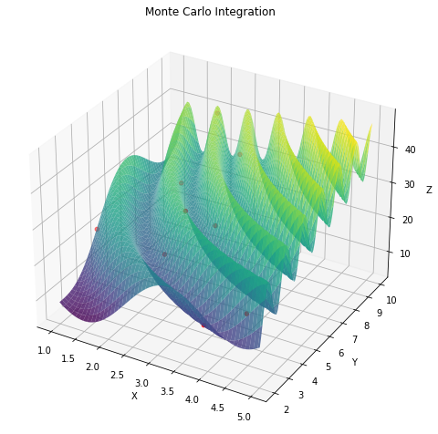

```
Интеграл методом Монте-Карло: 886.6175
Точное значение интеграла: 915.5070
Относительная ошибка: 3.1556%

========================================

Количество рандомных чисел: 50
```

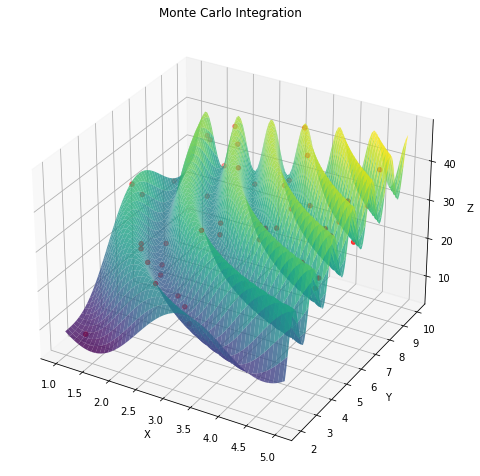

```
Интеграл методом Монте-Карло: 939.9341
Точное значение интеграла: 915.5070
Относительная ошибка: 2.6681%

========================================

Количество рандомных чисел: 100
```

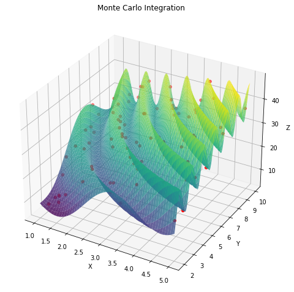

```
Интеграл методом Монте-Карло: 913.5059
Точное значение интеграла: 915.5070
Относительная ошибка: 0.2186%

========================================

Количество рандомных чисел: 500
```

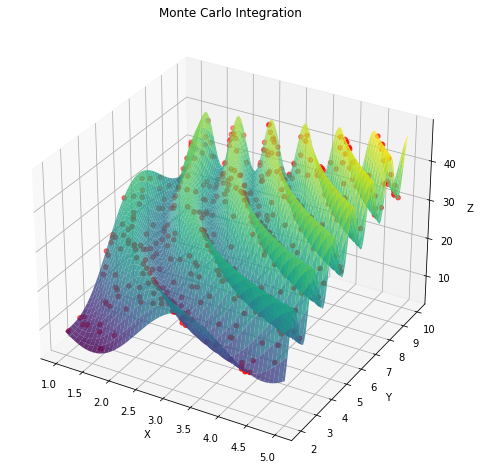

```
Интеграл методом Монте-Карло: 928.2416
Точное значение интеграла: 915.5070
Относительная ошибка: 1.3910%

========================================

Количество рандомных чисел: 1000
```

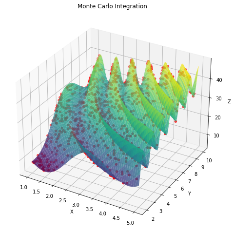

```
Интеграл методом Монте-Карло: 904.1887
Точное значение интеграла: 915.5070
Относительная ошибка: 1.2363%

========================================

Количество рандомных чисел: 5000
```

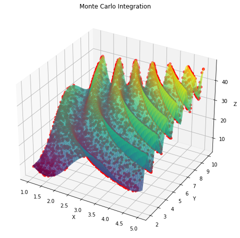

```
Интеграл методом Монте-Карло: 914.3816
Точное значение интеграла: 915.5070
Относительная ошибка: 0.1229%

========================================

Количество рандомных чисел: 10000
```

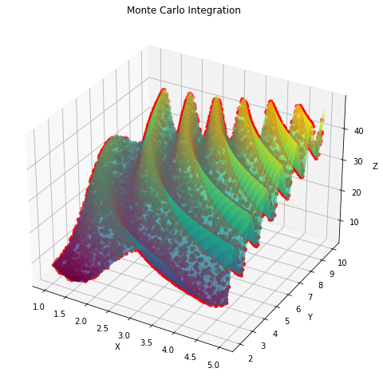

```
Интеграл методом Монте-Карло: 914.9913
Точное значение интеграла: 915.5070
Относительная ошибка: 0.0563%

========================================

Количество рандомных чисел: 50000
```

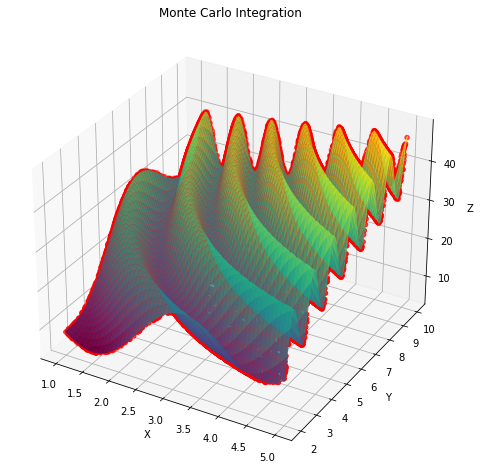

```
Интеграл методом Монте-Карло: 914.9127
Точное значение интеграла: 915.5070
Относительная ошибка: 0.0649%

========================================

Количество рандомных чисел: 100000
```

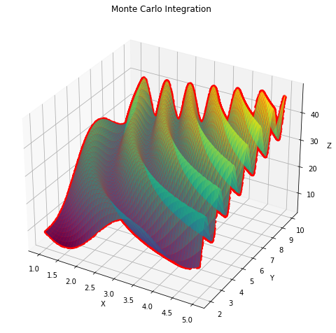

```
Интеграл методом Монте-Карло: 915.2692
Точное значение интеграла: 915.5070
Относительная ошибка: 0.0260%

========================================
```

```python
class MonteCarloIntegration:
    def __init__(self, func, a, b, c, d, N):
        self.func = func
        self.a = a
        self.b = b
        self.c = c
        self.d = d
        self.N = N
        self.array_x = np.random.uniform(a, b, N)
        self.array_y = np.random.uniform(c, d, N)

    def calculate_integral(self):
        summa = np.sum(self.func(self.array_x, self.array_y))
        integration = (self.b - self.a) * (self.d - self.c) / self.N * summa
        return integration

    def calculate_exact_integral(self):
        result, _ = nquad(self.func, [[self.a, self.b], [self.c, self.d]])
        return result

    def visualize_function(self):
        x_vals = np.linspace(self.a, self.b, 100)
        y_vals = np.linspace(self.c, self.d, 100)
        X, Y = np.meshgrid(x_vals, y_vals)
        Z = self.func(X, Y)
        fig = plt.figure(figsize=(8, 10))
        ax = fig.add_subplot(111, projection='3d')
        ax.plot_surface(X, Y, Z, cmap='viridis', alpha=0.8)
        ax.scatter(self.array_x, self.array_y, self.func(self.array_x, self.array_y), color='red', label='Random Points')

        ax.set_title('Monte Carlo Integration')
        ax.set_xlabel('X')
        ax.set_ylabel('Y')
        ax.set_zlabel('Z')
        plt.show()

if __name__ == "__main__":

    def custom_function(x, y):
        return np.sqrt(5*x**2 - 3*x + 5) + 13*np.log(y) + 7*np.cos(x*y)

    a = float(input("Введите нижний предел для x: "))
    b = float(input("Введите верхний предел для x: "))
    c = float(input("Введите нижний предел для y: "))
    d = float(input("Введите верхний предел для y: "))

    N_s = [10, 50, 100, 500, 1000, 5000, 10000, 50000, 100000]

    for N in N_s:

        print("Количество рандомных чисел:", N)

        monte_carlo = MonteCarloIntegration(custom_function, a, b, c, d, N)

        monte_carlo.visualize_function()

        integration = monte_carlo.calculate_integral()
        print(f"Интеграл методом Монте-Карло: {integration:.4f}")

        exact_integration = monte_carlo.calculate_exact_integral()
        print(f"Точное значение интеграла: {exact_integration:.4f}")

        error = abs(exact_integration - integration) / exact_integration * 100
        print(f"Относительная ошибка: {error:.4f}%")

        print("\n========================================\n")
```

# Решение обыкновенных диффренециальных уравнений с помощью метода Монте-Карло

## 1. Линейный случай

Пусть нам дано выражение следующего вида:

$\large \frac{\partial y}{\partial x} = f(x), \space y(x_0) = y_0$

Тогда мы можем записать решение, как:

$\large y(x) = y(x_0) + \int_{x_0}^{x} \partial \xi f(\xi) = $

$\large = y(x_0) + \Sigma_{i=1}^N \int_{x_{i-1}}^{x_i} \partial \xi f(\xi)$,

где мы определили $\large x_N = x$ и разделили интеграл на более мелкие дискретные фрагменты. Применяя метод Монте-Карло, мы можем переписать это следующим образом:

$\large y(x) = y(x_0) + \Sigma_{i=1}^N [\frac{x_i - x_{i-1}}{K} \Sigma_{k=1}^K f(x_k)]$

Мы можем еще немного упростить приведенное выше уравнение, пока не придем к итеративной процедуре:

$\large y(x_i) = y(x_{i-1}) + \frac{x_i - x_{i-1}}{K} \Sigma_{k=1}^K f(x_k)$

```
Количество рандомных чисел: 10
```

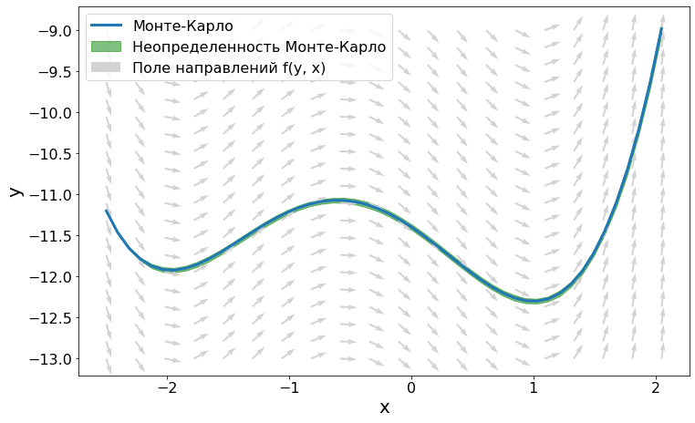

```
========================================

Количество рандомных чисел: 50
```

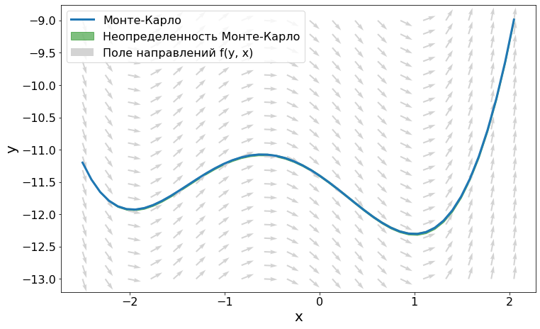

```
========================================

Количество рандомных чисел: 100
```

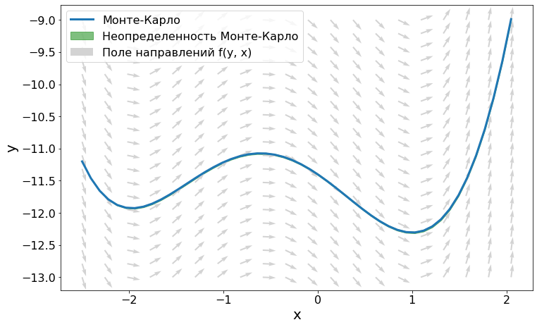

```
========================================

Количество рандомных чисел: 500
```

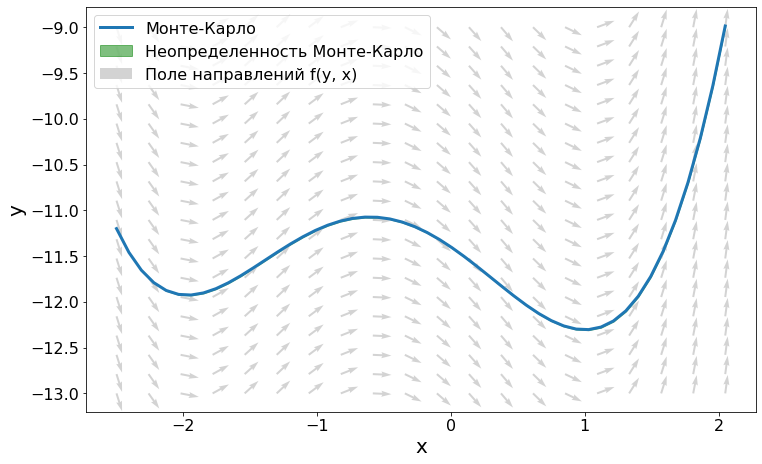

```
========================================

Количество рандомных чисел: 1000
```

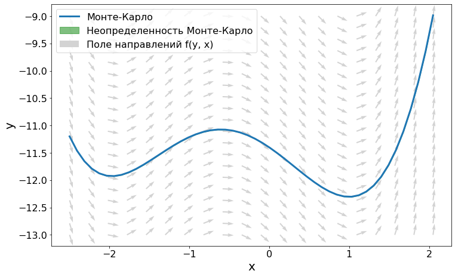

```python
class MonteCarloODESolver:
    def __init__(self, func: Callable):
        self.func = func

    def mc_int(self, domain: Tuple, n_samples: int):
        samples = np.random.uniform(low=domain[0], high=domain[1], size=(n_samples,))
        volume = abs(domain[1] - domain[0])
        return np.mean(self.func(samples)) * volume

    def solve_ode(self, y0, x, n_samples):
        vals = [y0]
        for lo, hi in zip(x[:-1], x[1:]):
            vals.append(vals[-1] + self.mc_int((lo, hi), n_samples))
        return np.asarray(vals)

    def plot_solution(self, xs, y_mean, y_std):
        width = 12
        height = width / 1.61
        fig, ax = plt.subplots(figsize=(width, height))

        ax.plot(xs, y_mean, linewidth=3, label='Монте-Карло')
        ax.fill_between(xs, y_mean - 3 * y_std, y_mean + 3 * y_std, alpha=.5, color='g', label='Неопределенность Монте-Карло')

        xx, yy = np.meshgrid(np.linspace(min(xs), max(xs), 20), np.linspace(-13, -9, 20))
        U = 1
        V = self.func(xx)
        N = np.sqrt(U**2 + V**2)
        U2, V2 = U/N, V/N

        ax.quiver(xx, yy, U2, V2, color='lightgray', label='Поле направлений f(y, x)')
        ax.set_xlabel(r'x', fontsize=20)
        ax.set_ylabel(r'y', fontsize=20)
        ax.tick_params(axis='both', which='major', labelsize=16)
        ax.tick_params(axis='both', which='minor', labelsize=12)
        ax.legend(loc='upper left', fontsize=16)
        plt.show()

if __name__ == "__main__":

    def func(x):
        return x**3 + 2 * x**2 - 3**x

    xs = np.linspace(-2.5, 2.05, 50)
    y0 = -11.2
    N_s = [10, 50, 100, 500, 1000]

    for N in N_s:

        print("Количество рандомных чисел:", N)

        solver = MonteCarloODESolver(func)
        ys = [solver.solve_ode(y0, xs, N) for _ in range(N)]
        y_mean = np.mean(ys, axis=0)
        y_std = np.std(ys, axis=0)

        solver.plot_solution(xs, y_mean, y_std)

        print("\n========================================\n")
```

## 2. Нелинейный случай

Данный подход легко обобщить на нелинейные ОДУ:

$\large y(x_i) = y(x_{i-1}) + \mathop{\mathbb{E}}_{x \sim U(x_{i-1}, x_i)} [f(y(x), x)]$

Правая часть теперь явно зависит от $\large y(x)$, т.е. в случайной точке мы просто производим выборку. Это значение, конечно, недоступно во время вычисления, и нам нужно сделать приближение, чтобы задачу выполнимой. Простое приближение состоит в замене:

$\large y(x_i) \rightarrow y(x_{i-1}) = y_{i-1}$

Это приводит к окончательному варианту:

$\large y(x_i) = y_{i-1} + \mathop{\mathbb{E}}_{x \sim U(x_{i-1}, x_i)} [f(y_{i-1}, x)]$

Чтобы продемонстрировать данное решение, рассмотрим нетривиальное градиентное поле:

$\large f(y, x) = x\sqrt(|y|) + sin^3(\frac{\pi}{2}x) - 5\Theta(x-2)$

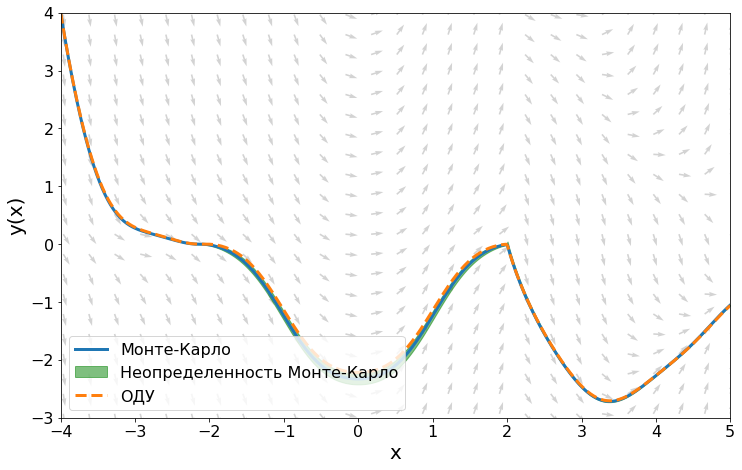

```python
class MonteCarloODESolver:
    def __init__(self, func: Callable):
        self.func = func

    def mc_int(self, func: Callable, domain: Tuple, n_samples: int):
        samples = np.random.uniform(low=domain[0], high=domain[1], size=(n_samples,))
        volume = abs(domain[1] - domain[0])
        return np.mean(func(samples)) * volume

    def mc_ode_solve(self, y0, t, n_samples=2):
        sols = [y0]
        for lo, hi in zip(t[:-1], t[1:]):
            part_func = lambda v: self.func(x=v, y=sols[-1])
            assert lo < hi
            sols.append(sols[-1] + self.mc_int(part_func, (lo, hi), n_samples=n_samples))
        return np.asarray(sols)

    def plot_solution(self, base, ys_mc, y_ode, y_mc_mean, y_mc_std):
        width = 12
        height = width / 1.61
        fig, ax = plt.subplots(figsize=(width, height))

        xx, yy = np.meshgrid(base, base)
        U = 1
        V = self.func(yy, xx)
        N = np.sqrt(U**2 + V**2)
        U2, V2 = U/N, V/N

        ax.quiver(xx, yy, U2, V2, color='lightgray')

        y_mc_mean = np.mean(ys_mc, axis=0)
        y_mc_std = np.std(ys_mc, axis=0)

        ax.plot(base2, y_mc_mean, linewidth=3, label='Монте-Карло')
        ax.fill_between(base2, y_mc_mean - 3 * y_mc_std, y_mc_mean + 3 * y_mc_std, color='g', alpha=0.5, label='Неопределенность Монте-Карло')

        y_ode = odeint(self.func, y0, base2)
        ax.plot(base2, y_ode, '--', linewidth=3, label='ОДУ')

        ax.set_xlabel(r'x', fontsize=20)
        ax.set_ylabel(r'y(x)', fontsize=20)
        ax.tick_params(axis='both', which='major', labelsize=16)
        ax.tick_params(axis='both', which='minor', labelsize=12)

        ax.legend(loc='lower left', fontsize=16)
        ax.set_xlim([-4, 5])
        ax.set_ylim([-3, 4])

        plt.show()

if __name__ == "__main__":
    def func(y, x):
        return x * np.sqrt(np.abs(y)) + np.sin(x * np.pi/2)**3 - 5 * (x > 2)

    base2 = np.linspace(-4, 5, 500)
    y0 = 4.
    ys_mc = []
    for _ in range(20):
        ys_mc.append(MonteCarloODESolver(func).mc_ode_solve(y0, base2))

    base = np.linspace(-5, 5, 30)
    y_ode = odeint(func, y0, base2)

    MonteCarloODESolver(func).plot_solution(base, ys_mc, y_ode, None, None)
```